# Statystki opisowe

Czas na poznanie rodzajów danych, na jakie możemy się natknąć.

W trakcie tych zajęć przedstawimy cztery podstawowe typy danych, dane ilościowe, jakościowe, napisy i wartości logiczne. Słowo typ, ma w tym przypadku to samo znaczenie co słowo rodzaj, ale jest częściej stosowane w analizie danych, dlatego będziemy poniżej mówić o czterech podstawowych typach.

Ale zanim dojdziemy do typów, wczytajmy dane

# Wczytanie danych

Na poprzednich zajęciach poznaliśmy kilka sposobów na wczytanie danych do R. Wczytajmy dane w formacie tekstowym używając funkcji `read.table()`. Następnie używając funkcji `head()` by wyświetlić pierwsze dwa wiersze.

```r
auta2012 = read.table("http://biecek.pl/MOOC/dane/auta2012.csv",
                       sep=";", dec=",", header=TRUE)
head(auta2012, 2)
```

```
##    Cena Waluta Cena.w.PLN Brutto.netto  KM  kW      Marka     Model Wersja
## 1 49900    PLN      49900       brutto 140 103        Kia    Carens
## 2 88000    PLN      88000       brutto 156 115 Mitsubishi Outlander
##   Liczba.drzwi Pojemnosc.skokowa Przebieg.w.km          Rodzaj.paliwa
## 1          4/5              1991         41000 olej napedowy (diesel)
## 2          4/5              2179         46500 olej napedowy (diesel)
##   Rok.produkcji Kolor Kraj.aktualnej.rejestracji Kraj.pochodzenia
## 1          2008                           Polska
## 2          2008                           Polska
##   Pojazd.uszkodzony Skrzynia.biegow Status.pojazdu.sprowadzonego
## 1                          manualna
## 2                          manualna
##                                                                                                                                                                                Wyposazenie.dodatkowe
## 1                         ABS, el. lusterka, klimatyzacja, alufelgi, centralny zamek, autoalarm, poduszka powietrzna, radio / CD, wspomaganie kierownicy, immobiliser, komputer, przyciemniane szyby
## 2 ABS, 4x4, el. lusterka, klimatyzacja, skorzana tapicerka, alufelgi, centralny zamek, poduszka powietrzna, radio / CD, wspomaganie kierownicy, immobiliser, komputer, tempomat, przyciemniane szyby
##   Informacje.dodatkowe
## 1  pierwszy wlasciciel
## 2  pierwszy wlasciciel
```

Każdy wiersz tego zbioru danych opisuje jedną ofertę sprzedaży auta. Każda kolumna opisuje jedną cechę / właściwość tej oferty.

# Cechy ilościowe

Przyjrzyjmy się takim cechom jak *Cena.w.PLN* lub *Przebieg.w.km*. Cechy te są opisane przez liczby oraz przedstawiają ilości. Pierwsza z nich przedstawia *ilość* pieniędzy, za którą sprzedawca chce sprzedać samochód, druga opisuje *ilość* kilometrów, którą przejechał wystawiony na aukcji samochód.

## Statystyki opisowe

Na zmiennych ilościowych wykonać możemy kilka operacji. Używając funkcji `mean()` możemy policzyć średnią cenę wystawionych aut.

```r
mean(auta2012$Cena.w.PLN)
```

```
## [1] 35409
```

Używając funkcji `min()` i `max()` możemy wyznaczyć minimalną i maksymalną cenę w tym zbiorze danych.

```r
min(auta2012$Cena.w.PLN)
```

```
## [1] 400
```

```r
max(auta2012$Cena.w.PLN)
```

```
## [1] 2953960
```

Używając funkcji `summary()` możemy wyznaczyć sześć podstawowych charakterystyk, czyli: minimum, 1. kwartyl, medianę (2. kwwartyl), średnią, 3. kwartyl i maksimum.

```r
summary(auta2012$Cena.w.PLN)
```

```
##    Min. 1st Qu.  Median    Mean 3rd Qu.    Max.
##     400   10900   19900   35400   37000 2950000
```

### Zadania:

- W zbiorze danych *auta2012* aż 7 cech to cechy ilościowe. Wymień które.
- Jedną z cech ilościowych jest *Rok.produkcji*. Jaki jest medianowy/połówkowy rok produkcji oferowanych aut? Wszystkie te oferty były złożone w roku 2012, jaki był medianowy/połówkowy wiek oferowanego auta?

### Odpowiedzi:

- `Cena`, `Cena.w.PLN`, `KM`, `kW`, `Pojemnosc.skokowa`, `Przebieg.w.km`, `Rok.produkcji`
- 2004 rok

## Brakujące dane

Może się tak zdarzyć, że oferta sprzedaży nie zawiera wszystkich informacji o aucie. Np. brakuje informacji o przebiegu. Takie braki danych trzeba jakoś oznaczyć. Nie można w ich miejsce wstawić np. 0, ponieważ czymś innym jest przebieg równy 0 a czymś innym jest brak informacji o przebiegu.

Potrzebna jest więc jakaś specjalna wartość, która będzie oznaczała brakujące wartości. W programie R taką wartością jest `NA` (skrót od *non available*, czyli *niedostępne*).

```r
summary(auta2012$Przebieg.w.km)
```

```
##     Min.  1st Qu.   Median     Mean  3rd Qu.     Max.     NA's
## 1.00e+00 8.60e+04 1.40e+05 1.45e+05 1.80e+05 1.00e+09    20712
```

Jakie są konsekwencje występowania brakujących wartości? Część statystyk nie można policzyć. Przykładowo, średnia z 1 i 3 to 2. Ale ile wynosi średnia z 1 i *nie wiadomo*?

Dlatego gdy liczmy średnie lub inne statystyki z takich wektorów to wynik jest wartością `NA`.

```r
mean(auta2012$Przebieg.w.km)
```

```
## [1] NA
```

```r
min(auta2012$Przebieg.w.km)
```

```
## [1] NA
```

```r
max(auta2012$Przebieg.w.km)
```

```
## [1] NA
```

To logiczne. Jeżeli nie wszystkie wartości są znane, to nie można policzyć ani średniej ani minimum ani maksimum.

Logiczne ale też mało praktyczne. Często chcielibyśmy policzyć średnią, medianę, minimum tylko z tych wartości które są znane.

Aby to zrobić w programie R, do funkcji należy dodać argument `na.rm=TRUE`, gdzie `na.rm` to skrót od *remove NA*, czyli usuń wartości brakujące.

```r
mean(auta2012$Przebieg.w.km, na.rm=TRUE)
```

```
## [1] 144732
```

```r
min(auta2012$Przebieg.w.km, na.rm=TRUE)
```

```
## [1] 1
```

```r
max(auta2012$Przebieg.w.km, na.rm=TRUE)
```

```
## [1] 1e+09
```

### Zadania:

- Która cecha jest najmniej kompletna? Dla której cechy liczba brakujących wartości jest największa?
- Jaka jest mediana/połówkowa wielkość silnika (`Pojemnosc.skokowa`)?

## Graficzne statystyki opisowe

Powyżej opisane statystyki liczbowe można przedstawić graficznie. Prezentacja graficzna ma tę zaletę, że wyćwiczone oko potrafi szybko wiele dowiedzieć się z danych.

Opisując zmienną ilościową mamy do wyboru różne sposoby prezentacji, w zależności od tego ile informacji chcemy przedstawić.

Przypuśćmy, że chcemy pokazać wyłącznie średnią. Jedną liczbę. Zrobimy to za pomocą wykresu słupkowego. Wykres słupkowy można w programie R wyznaczyć funkcją `barplot()`.

```r
(srednia = mean(auta2012$Przebieg.w.km, na.rm=TRUE))
```

```
## [1] 144732
```

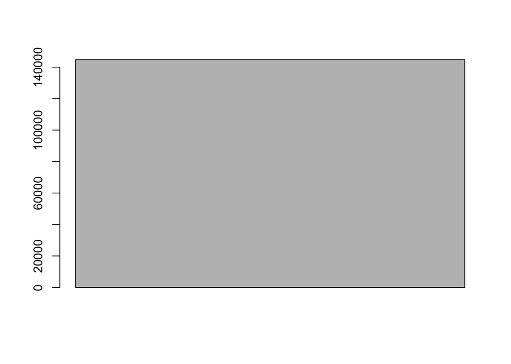

```r
barplot(srednia)
```

Jeden słupek wygląda dziwnie, mało czytelnie. To dlatego, że wykres przedstawia jedną liczbę, trudno więc do czegoś się na nim odnieść.

Ciekawszy będzie wykres, przedstawiający więcej informacji. Powyżej pokazaliśmy wynik funkcji `summary()`, prezentujących sześć charakterystycznych informacji o rozkładzie (min, max, kwartyle i średnią). Pięć z nich, za wyjątkiem średniej, przedstawia wykres pudełko-wąsy, który w R można wykonać używając funkcji `boxplot()`.

W poniższym przykładzie przedstawiamy te pięć liczb dla zmiennej `Przebieg.w.km`. Argument `horizontal=TRUE` powoduje, że wykres rysowany jest poziomo, argument `range = 0` powoduje, że nie są wyznaczane wartości odstające (a nie mówiliśmy co to za wartości, więc ich nie wyznaczajmy, wrócimy do tego tematu później).

```r
summary(auta2012$Przebieg.w.km)
```

```
##     Min.  1st Qu.   Median     Mean  3rd Qu.     Max.     NA's
## 1.00e+00 8.60e+04 1.40e+05 1.45e+05 1.80e+05 1.00e+09    20712
```

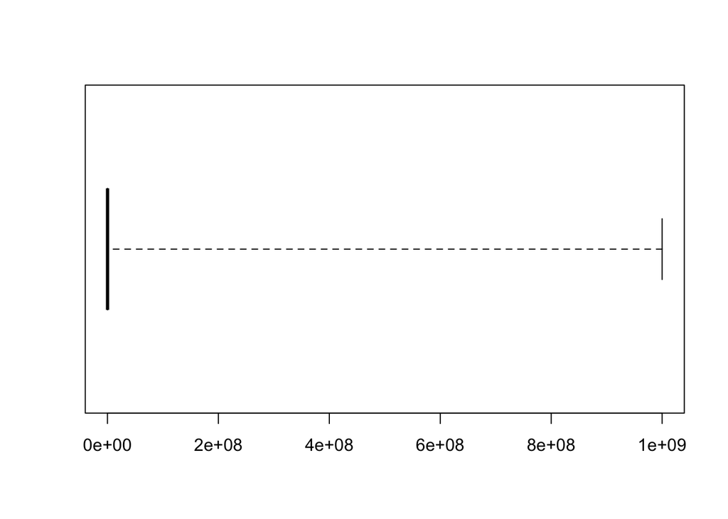

```r
boxplot(auta2012$Przebieg.w.km,
        horizontal=TRUE, range = 0)
```

Dane bardzo często są zanieczyszczone a graficzne prezentacje pozwalają nam to łatwo zauważyć. Tak jest i w tym przypadku. Oczyśćmy te dane, usuwając wszystkie wiersze, dla których cecha `Przebieg.w.km` przyjmuje wartości powyżej 1 000 000 km. Takie czyszczenie możemy przeprowadzić używając funkcji `filter()` z pakietu `dplyr`.

```r
library(dplyr)
auta2012wybrane <- auta2012 %>%
  filter(Przebieg.w.km < 1000000)

summary(auta2012wybrane$Przebieg.w.km)
```

```
##    Min. 1st Qu.  Median    Mean 3rd Qu.    Max.
##       1   86000  140000  133000  180000  700000
```

Teraz możemy narysować wykres pudełko-wąsy dla oczyszczonych danych.

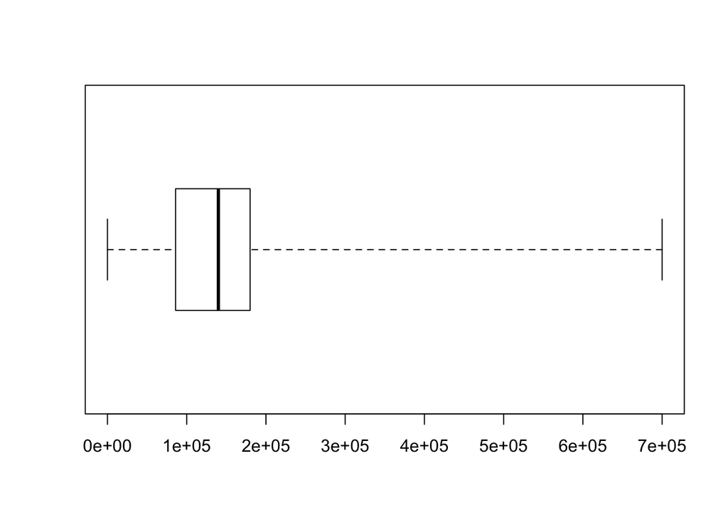

```r
boxplot(auta2012wybrane$Przebieg.w.km, horizontal=TRUE, range=0)
```

Każdy z elementów tego wykresu (lewy wąs, lewa część pudełka, prawa część pudełka, prawy wąs) przedstawia 1/4 danych. Z wykresu tego możemy łatwo odczytać, że 3/4 danych dotyczy aut o przebiegu poniżej 200 tys km. Jedynie 1/4 danych ma wyższe wartości i dla tych aut rozpiętość jest bardzo duża.

Jeżeli chcemy zaprezentować bardziej szczegółowe dane o przebiegu, możemy wykorzystać histogram. Słowo histogram pochodzi z języka greckiego, pochodzi ze złożenia słów histos i gramma. Pierwsze oznacza rzeczy stojące pionowo, drugie oznacza zapis. W sumie chodzi o przedstawienie danych z użyciem pionowych słupków.

Aby wykonać w programie R histogram, można wykorzystać funkcję `hist()`. Pierwszy argument określa dane, które mają być pokazane, drugi argument określa na ile przedziałów ma być podzielony zakres zmienności. Histogram przedstawia liczbę samochodów, których przebieg jest w zakresie opisanym przez określone pudełko.

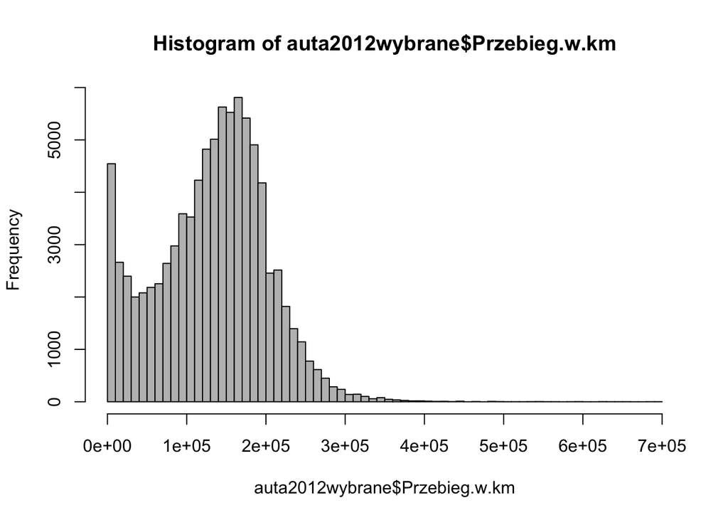

```r
hist(auta2012wybrane$Przebieg.w.km, 60, col="grey")
```

Jak widzimy zmienną ilościowa możemy opisać z różnym poziomem szczegółowości. Im większa szczegółowość tym więcej elementów na wykresie. Im więcej elementów tym więcej możemy odczytać ale jest to też trudniejsze.

### Zadania:

- Przedstaw graficznie za pomocą wykresu pudełko-wąsy oraz histogramu rozkład cechy `Cena.w.PLN`.
- Zwróć uwagę, że pojedyncze auta o bardzo wysokich cenach, powodują że wykres jest mało czytelny. Oczyść te dane, pozostawiają tylko auta o cenie poniżej 100 tys pln. Następnie przedstaw rozkład cen aut w segmencie aut do 100 tys pln.
- Aut w jakiej cenie jest najwięcej wśród zebranych ogłoszeń?

### Odpowiedzi:

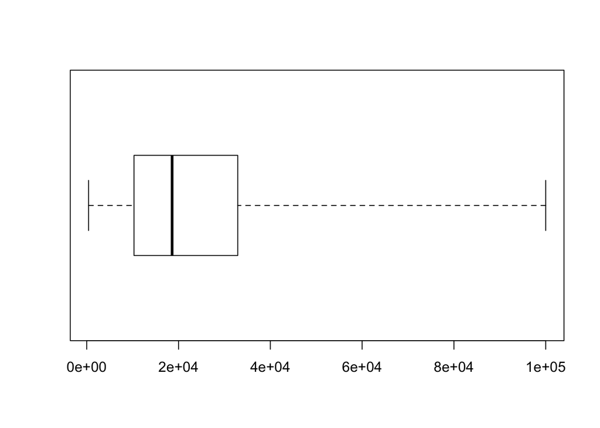

```r
library(dplyr)
auta2012wybrane <- auta2012 %>%
  filter(Cena.w.PLN < 100000)

boxplot(auta2012wybrane$Cena.w.PLN, horizontal = TRUE, range = 0)
```

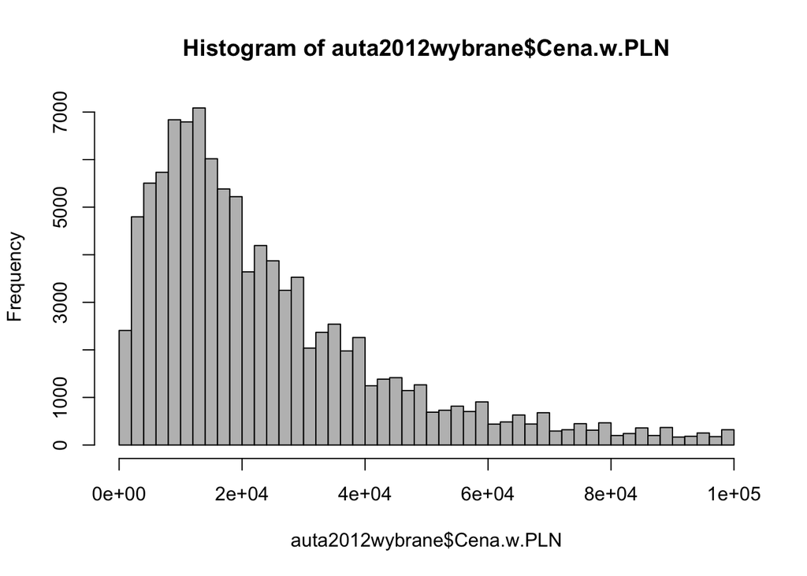

```r
hist(auta2012wybrane$Cena.w.PLN, 50, col="grey")
```

# Cechy jakościowe

Przyjrzyjmy się teraz takim cechom jak `Waluta` lub `Marka`. Cechy te są opisane przez wartości z określonej listy możliwości. Dla cechy `Waluta` lista możliwości to CHF, CZK, EEK, EUR, GBP, HUF, PLN, USD. Takie cechy określa się cechami jakościowymi w odróżnieniu od cech ilościowych.

## Statystyki opisowe

Dla cech jakościowych możemy wykonać kilka operacji. Jedną z nich jest wyświetlenie listy możliwych wartości. Taką listę nazywa się często słownikiem (spisem możliwych wartości).

Listę możliwych wartości dla zmiennej jakościowej można wyznaczyć funkcją `levels()`.

```r
levels(auta2012$Waluta)
```

```
## [1] "CHF" "CZK" "EEK" "EUR" "GBP" "HUF" "PLN" "USD"
```

Zmienne jakościowe często opisuje się tablicą liczebności, a więc informacją ile razy wystąpiła każda z wartości ze słownika. Tablicę liczebności można wyznaczyć funkcją `table()` lub `summary()`.

```r
table(auta2012$Waluta)
```

```
##
##   CHF   CZK   EEK   EUR   GBP   HUF   PLN   USD
##     1 12053     1  2810     4   242 94008   444
```

```r
summary(auta2012$Waluta)
```

```
##   CHF   CZK   EEK   EUR   GBP   HUF   PLN   USD
##     1 12053     1  2810     4   242 94008   444
```

### Zadania:

- Ile zmiennych w zbiorze danych `auta2012` to zmienne jakościowe?
- Zmienna `Liczba.drzwi` przyjmuje wartości `2/3` i `4/5`. Zachowuje się ona jako zmienna jakościowa. Jednak można uznać, że liczba drzwi to cecha ilościowa, ponieważ opisuje *ilość* drzwi w samochodzie. Jak wyjaśnić tę dualność?

### Odpowiedzi:

- Waluta, Brutto.netto, Marka, Model, Wersja, Liczba.drzwi, Rodzaj.paliwa, Kolor, Kraj.aktualnej.rejestracji, Kraj.pochodzenia, Pojazd.uszkodzony, Skrzynia.biegow, Status.pojazdu.sprowadzonego, Wyposazenie.dodatkowe, Informacje.dodatkowe
- Pewne zmienne, w zależności od kontekstu, mogą być traktowane i analizowane jak zmienne ilościowe lub zmienne jakościowe. Do nas należy wybór, która z tych opcji jest właściwsza.

## Procenty

W pewnych sytuacjach, zamiast posługiwać się tablicą liczebności, wygodniej jest posługiwać się tabelą z procentami. Ale jak te procenty policzyć? Pokażemy to na przykładzie kilku funkcji.

Funkcja `prop.table()` dzieli wartości tabeli liczebności przez sumę liczebności, a więc zamienia liczebności na frakcje. Przypiszmy wynik funkcji `table()` do jakiejś zmiennej, np. o nazwie `tabela` (nazwa może być dowolna, musimy jej jednak konsekwentnie używać w dalszych przykładach). Następnie tak otrzymaną tabelę liczebności zamieniamy na frakcje.

W poniższym przykładzie, instrukcję przypisania wyniku obejmujemy napisami, po to by jej wynik był wyświetlony. Bez nawiasów wynik funkcji `table()` nie zostałby wyświetlony.

```r
(tabela = table(auta2012$Waluta))
```

```
##
##   CHF   CZK   EEK   EUR   GBP   HUF   PLN   USD
##     1 12053     1  2810     4   242 94008   444
```

```r
prop.table(tabela)
```

```
##
##       CHF       CZK       EEK       EUR       GBP       HUF       PLN
## 9.127e-06 1.100e-01 9.127e-06 2.565e-02 3.651e-05 2.209e-03 8.580e-01
##       USD
## 4.052e-03
```

Zazwyczaj chcemy mieć wyznaczone procenty a nie frakcje. I to nie byle jakie procenty, ale procenty które są ładnie sformatowane, np. wyświetlone z dokładnością do jednego miejsca dziesiętnego po przecinku. Aby zamienić frakcje na procenty, wystarczy je przemnożyć przez 100, a aby wynik przedstawić z dokładnością do jednego miejsca po przecinku wykorzystamy funkcję `round()`.

```r
(tabela = table(auta2012$Waluta))
```

```
##
##   CHF   CZK   EEK   EUR   GBP   HUF   PLN   USD
##     1 12053     1  2810     4   242 94008   444
```

```r
(frakcje = prop.table(tabela))
```

```
##
##       CHF       CZK       EEK       EUR       GBP       HUF       PLN
## 9.127e-06 1.100e-01 9.127e-06 2.565e-02 3.651e-05 2.209e-03 8.580e-01
##       USD
## 4.052e-03
```

```r
procenty = 100*frakcje
round(procenty, digits = 1)
```

```
##
##  CHF  CZK  EEK  EUR  GBP  HUF  PLN  USD
##  0.0 11.0  0.0  2.6  0.0  0.2 85.8  0.4
```

Ostatnim usprawnieniem tego procesu, które warto rozważyć to uporządkowanie wartości rosnąco lub malejąco. Mając wiele możliwości, w gąszczu liczb czasem trudno nawet dostrzec, która jest największa. Posortowawszy te liczby łatwiej dostrzec najmniejsze i największe. Do sortowania można wykorzystać funkcję `sort()`. Dodając argument `decreasing = TRUE` powodujemy, że wartości będą uporządkowane malejąco.

```r
zaokragloneProcenty = round(procenty,1)
sort(zaokragloneProcenty)
```

```
##
##  CHF  EEK  GBP  HUF  USD  EUR  CZK  PLN
##  0.0  0.0  0.0  0.2  0.4  2.6 11.0 85.8
```

```r
sort(zaokragloneProcenty, decreasing = TRUE)
```

```
##
##  PLN  CZK  EUR  USD  HUF  CHF  EEK  GBP
## 85.8 11.0  2.6  0.4  0.2  0.0  0.0  0.0
```

### Zadania:

- Cecha `Marka` opisuje markę samochodu. Sprawdź, która marka jest najpopularniejsza.
- Cecha `Rodzaj.paliwa` opisuje rodzaj paliwa wykorzystywanego przez auto. Czy jest to benzyna, olej, gaz? Sprawdź jaki procent samochodów jest napędzana na benzynę.

### Odpowiedzi:

- Volkswagen
- 38.6882 %

## Graficzne statystyki opisowe

Tabele liczebności są proste w interpretacji. Podobnie jednak jak w innych przypadkach, graficzne przedstawienie tych liczb pozwala na łatwiejsze dostrzeżenie zależności pomiędzy danymi. Koniec końców w tabeli liczb łatwo pomylić się nawet gdy chodzi o liczbę cyfr w licznie. Na wykresie takie różnice natychmiast rzucają się w oczy.

```r
(tabela = table(auta2012$Waluta))
```

```
##
##   CHF   CZK   EEK   EUR   GBP   HUF   PLN   USD
##     1 12053     1  2810     4   242 94008   444
```

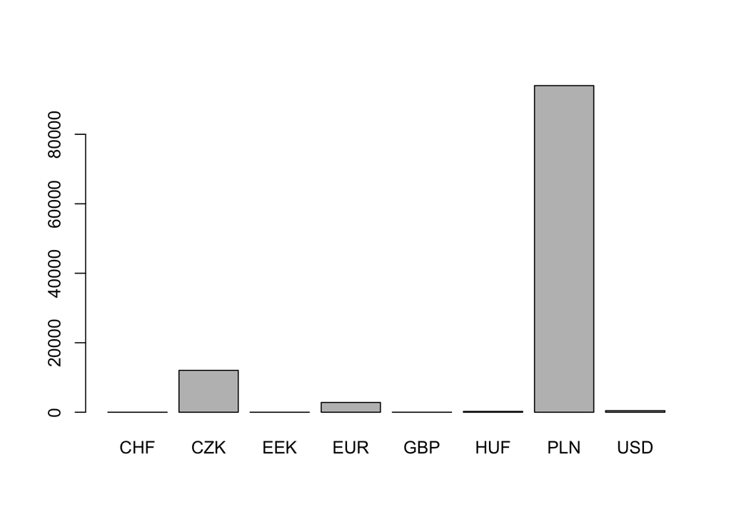

```r
barplot(tabela)
```

Jeżeli chcemy, by słupki były przedstawiane poziomo, można dodać argument `horiz = TRUE`.

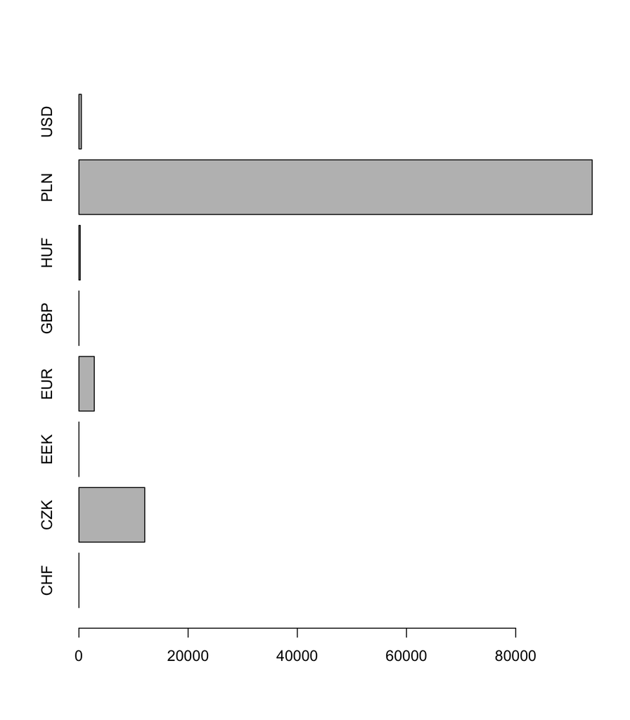

```r
barplot(tabela, horiz = TRUE)
```

Domyślnie wartości są uporządkowane alfabetycznie. Nie zawsze jednak taka kolejność ma sens. W tym przypadku rozsądniej jest posortować dane malejąco, co można wykonać z użyciem funkcji `sort()`. Argument `las=1` powoduje, że oś OY ma etykiety ustawione poziomo.

```r
(posortowanaTabela = sort(tabela))
```

```
##
##   CHF   EEK   GBP   HUF   USD   EUR   CZK   PLN
##     1     1     4   242   444  2810 12053 94008
```

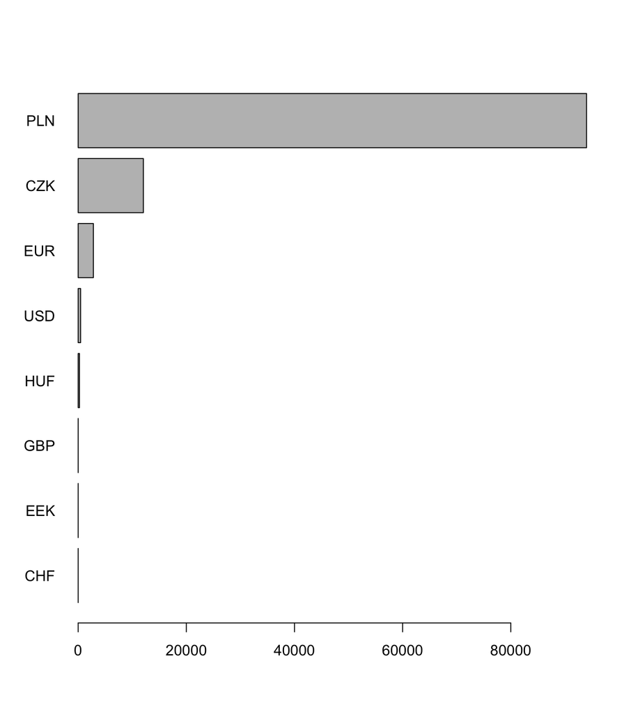

```r
barplot(posortowanaTabela, horiz = TRUE, las=1)
```

### Zadania:

- Przedstaw graficznie tabelę liczebności dla zmiennej `Kraj.pochodzenia`. Wypróbuj wykres pionowy i poziomy. Aby obrócić kierunek etykiet na osiach dodaj do funkcji `barplot()` argument `las=1`.

### Odpowiedzi:

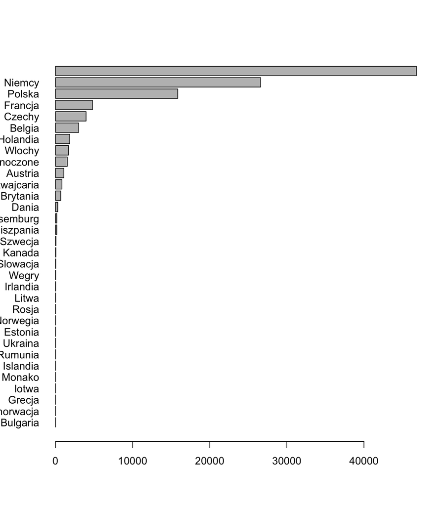

```r
posortowanaTabela = sort(table(auta2012$Kraj.pochodzenia))
barplot(posortowanaTabela, horiz = TRUE, las=1)
```

Podobnie graficznie można przedstawiać cechy logiczne i napisowe.

# Cechy logiczne

Każdą zmienną można przedstawić jako zmienną jakościową lub ilościową. Ale w pewnych sytuacjach wygodnie jest wyróżnić bardziej szczegółową klasyfikację. Cechy logiczne, to takie cechy, które przyjmować mogą tylko trzy wartości, prawdę (oznaczany w R przez `TRUE`), fałsz (oznaczany w R przez `FALSE`) oraz brak informacji (oznaczany w R przez `NA`).

Cechy logiczne mogą być traktowane jako cechy jakościowe o dwóch poziomach. Cechy takie można tworzyć używając tak zwanych warunków logicznych. Przykładem warunku logicznego są operatory `>` (większy), `>=` (większy równy), `==` (równy), `<=` (mniejszy równy), `<` (mniejszy).

## Statystyki opisowe

Traktując zmienną logiczną jak dwuwartościową zmienną jakościową, możemy używać na niej np. funkcji do tabel liczebności.

```r
pochodziZPolski = auta2012$Kraj.aktualnej.rejestracji == "Polska"
table(pochodziZPolski)
```

```
## pochodziZPolski
## FALSE  TRUE
## 62810 46753
```

```r
starszyNiz5Lat = auta2012$Rok.produkcji < 2007
table(starszyNiz5Lat)
```

```
## starszyNiz5Lat
## FALSE  TRUE
## 35264 74298
```

### Zadania:

- Sprawdź ile samochodów ma cenę ofertową poniżej 2 000 pln.
- Sprawdź jaki procent samochodów ma silniki o pojemności ponad 1500 cm3.

### Odpowiedzi:

- 2235
- 0.7735

## Logiczne ‘i’ oraz logiczne ‘lub’

Cechy logiczne można przetwarzać używając również operatorów logicznych, w tym logicznego lub `|` oraz logicznego i `&`.

```r
pochodziZPolski = auta2012$Kraj.aktualnej.rejestracji == "Polska"
starszyNiz5Lat = auta2012$Rok.produkcji < 2007
pochodziZPolskiIStarszyNiz5Lat = pochodziZPolski & starszyNiz5Lat
table(pochodziZPolskiIStarszyNiz5Lat)
```

```
## pochodziZPolskiIStarszyNiz5Lat
## FALSE  TRUE
## 74629 34934
```

### Zadania:

- Sprawdź ile samochodów zarejestrowanych w Polsce ma cenę ofertową poniżej 2 000 pln.
- Sprawdź jaki procent samochodów ma silniki o pojemności ponad 1500 cm3 oraz jest napędzanych olejem napędowym.

### Odpowiedzi:

- 1031
- 0.4886

# Cechy napisowe

Funkcja `read.table()` wczytując tekst zamienia go na zmienną jakościową. W pewnych sytuacjach chcemy jednak na napisach wykonywać specjalne operacje. Takie np. jak wyszukiwanie podciągu w tekście.

Aby to zrobić, musimy w pierwszej kolejności zamienić zmienna jakościową na zmienną napisową. Konwersję cechy z cechy jakościowej na cechę napisową można wykonać funkcją `as.character()`

```r
auta2012$Wyposazenie.dodatkowe.napis = as.character(auta2012$Wyposazenie.dodatkowe)
summary(auta2012$Wyposazenie.dodatkowe.napis)
```

```
##    Length     Class      Mode
##    109563 character character
```

## Statystyki opisowe

Jedną z interesujących operacji na napisach, jest sprawdzenie, czy zawierają one określony podciąg znaków. Taki test można wykonać funkcją `grepl()`, która jako wynik zwraca wartość logiczną określającą czy napis zawiera określony wzorzec czy nie.

```r
maKlimatyzacje = grepl(auta2012$Wyposazenie.dodatkowe.napis, pattern="klimatyzacja")
table(maKlimatyzacje)
```

```
## maKlimatyzacje
## FALSE  TRUE
## 23534 86029
```

```r
auta2012$Informacje.dodatkowe.napis = as.character(auta2012$Informacje.dodatkowe)
bezwypadkowy = grepl(auta2012$Informacje.dodatkowe.napis, pattern="bezwypadkowy")
table(bezwypadkowy)
```

```
## bezwypadkowy
## FALSE  TRUE
## 53193 56370
```

### Zadania:

- Sprawdź ile samochodów ma zainstalowany autoalarm
- Sprawdź ile samochodów ma lakier w metalicznym kolorze

### Odpowiedzi:

- 48092
- 74512